# POLI 110 Investigating Politics

September 17, 2026

## What do we mean by “Truth”?

## Objectives

Getting to the Truth is important…

But what is “truth”?

1. What is a **claim**?
2. What types of **claims** are there?
3. What do we mean by **truth**?
4. What kinds of claims can be judged scientifically?

## Recap

## Three Reasons we need Truth in Politics

## But what do we mean by **truth**?

### **What kinds of *claims* to truth do we make?**

### **What is our approach to *knowing* or *finding* truth?**

## Reasons and Claims

## Power involves giving Reasons

Forst says that power involves *giving reasons* to motivate people to change what they think and do.

Those *reasons* can be thought of a *claims* about what is true.

Whether a reason is *good* depends on the *basis* for the claim.

## Two Key definitions

### **claim**:

(For our purposes) a statement about what is **valid** or **true** or **right**.

- If you can add “is true” to the end or “it is true that”/“it is correct to say that” to the beginning of the statement without changing the meaning, it is a (validity) claim.

### Don’t overthink this definition. It is as simple as it seems.

## Two Key definitions

### **basis**:

(For our purposes) the basis for a claim is the *reason* we should accept the validity of that claim. It includes

- the **evidence** that is used to “prove” the claim is true
- and the **warrant**: assumptions required for the evidence to be valid “proof”

colloquially, we refer to both parts as “evidence”

## An example:

### **claim**: “It rained last night.”

### **basis**: “I looked outside and can see the street is wet.”

What is the **evidence**?

What are the **assumptions** linking that evidence to the claim?

[video not shown]

What claims are in this ad? Bases for these claims?

## Varieties of Claims

### Three dimensions

1. **Empirical vs. Normative**
2. **Varieties** of empirical and **normative claims/questions**
3. Falsifiable vs. unfalsifiable

## Empirical Claims

#### **empirical claim**:

is a claim about **what is/what exists** in the world or **how things that exist affect each other**.

## Normative Claims

#### **normative claim**:

is a claim about **what is desirable or undesirable**, good or bad.

- assert what **should or should not** be.
- “should” implied by the language of “right”/“wrong”
- “should” implied by “too much”, “enough”, or “not enough” of something.
- “should” implied by standards for what is “better”/“worse”

Return to the board: look at the reasons/claims given in the ad

- which are empirical? which are normative?

## Empirical Claims

## Descriptive claims:

claims about what exists (or has existed/will exist) in the world:

- **what phenomena exist** (what kinds of things exist?)
- **what is the type of a specific phenomenon** (what is this thing?)
- **amount/frequency of phenomena** (how much of something is there?)
- **relative amount/frequency of phenomena across different places/times** (how much of something is there here vs. there/now vs. then?)
- **what patterns are there in the shared appearance of different phenomena** (does *this* thing usually appear together with *that* other thing?)

## Causal claims:

### **causal claims**:

are claims about the how one phenomena (\(X\)) affects or causes another phenomena (\(Y\)). Causal claims state that \(X\) **acts on** \(Y\) in some way, not merely that they appear together in some pattern:

- the **effect** that one thing or event has on another thing (effects of causes)
- the **cause** of some event or thing in the world (causes of effects)
- the *conditions* under which some thing or event *happens* (causes of effects)
- the *process* through which one thing affects another (causes of effects)

## Causal or Descriptive?

1. Canada’s trade surplus with the United States has grown over the past decade.
2. The 2018 steel and aluminum tariffs caused Canadian producers to shift their sales toward domestic and overseas markets.
3. Canadian provinces most dependent on U.S. exports have higher unemployment rates than those with more diversified trade relationships.
4. U.S. tariffs on Canadian softwood lumber have reduced Canadian forestry employment.
5. Canada *should* deepen its trade partnership with the European Union rather than trying to restore access to U.S. markets.

## Normative Claims

## Normative Claims:

#### **value judgments**:

are normative claims that

- state what goal or ideal is “right” or “good”
- or provide criteria/rules for judging what is “better” or “worse”.
- often implied.

#### **They are not:**

- empirical claims for which the evidence is **invalid or missing**
- empirical claims that we can’t persuade someone to drop in the face of better evidence

## Flat Earth!

[figure not shown]

## Flat Earth?

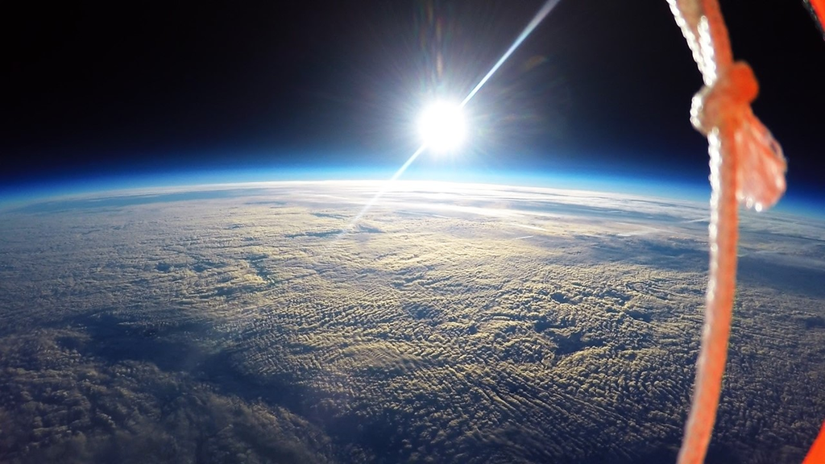

[‘Associate member’ of the EU? Why not, Canada?](https://www.theglobeandmail.com/business/commentary/article-associate-member-of-the-eu-why-not-canada/)

But taking into account both the benefits and costs, there exists considerable potential for EU associate membership to be a net win for Canada.

Integrating our military production with the EU would benefit our industry since Canadian manufacturing is struggling with the Trump tariffs. If Canada were part of EU defence procurement, we might see the commercial demand that would justify using defence manufacturing to replace declining auto manufacturing. …The EU seems to want countries such as Canada to expand supply of these commodities. So, I would expect a satisfactory arrangement could be made allowing Canada to have higher than normal carbon emissions. Would the EU tolerate our provincial restrictions on trade and labour mobility given that equivalent restrictions are not allowed within the EU? Probably not and it actually could be a really good thing for Canada. … These domestic restrictions are a major drag on the Canadian economy.

The European bureaucracy and complex regulations spring to mind as a key cost. It is possible that EU red tape might further slow innovation in Canada, but the reality is that we already have a lot of red tape and slow innovation, so negotiations may not lead to much growth in red tape. It could in fact lead to less red tape because Canada, which has resolved to cut red tape, has the potential to nudge the EU bureaucracy in a better direction.

However much U.S. President Trump would be displeased by Canada’s closer ties to the EU, it is unclear that he would further punish us in terms of tariffs, for fear of a backlash by his own voters already worried about affordability. Mr. Carney should continue to pursue closer ties with the EU.

## Prescriptive Claims

#### **prescriptive claims**:

are normative claims that assert what kinds of actions **should** be taken

- hint: like a doctor or pharmacist, it *prescribes* a course of action.
- there is a connection to reasons given by power.

Return to the board: look at the reasons/claims given in the ad

- which are descriptive? causal? value judgments? prescriptive claims?

## Truth

## How do we know something is true?

- Reality \(\to\) Mind

What shapes do you see?

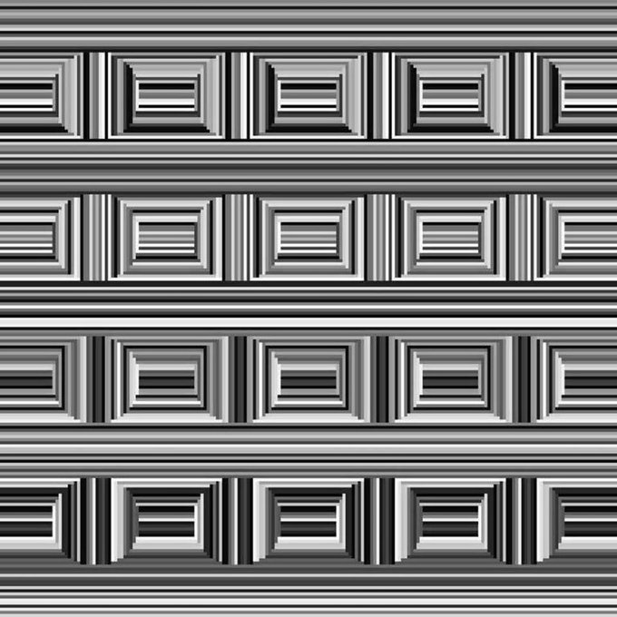

What color are these fruits?

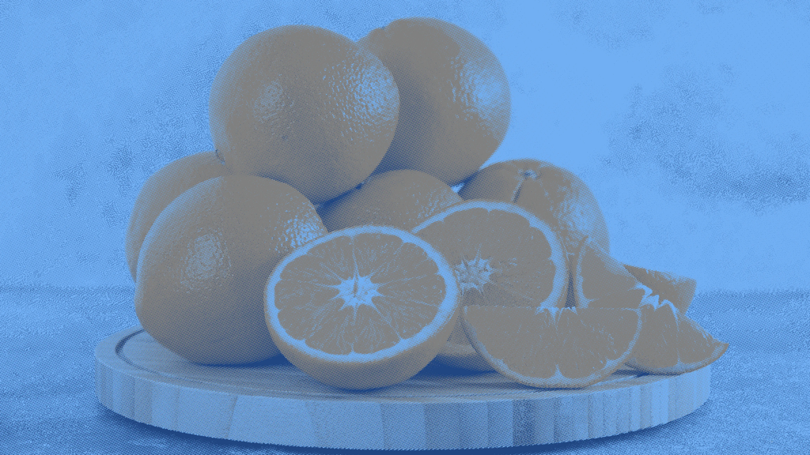

What color are these chess pieces?

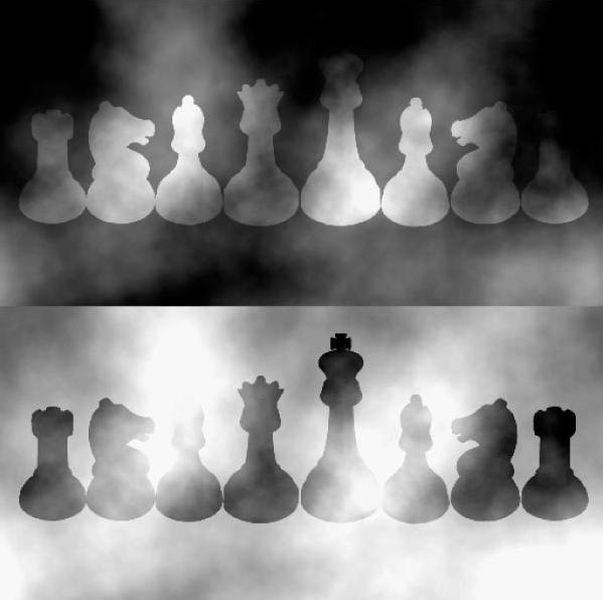

What color are these fruits?

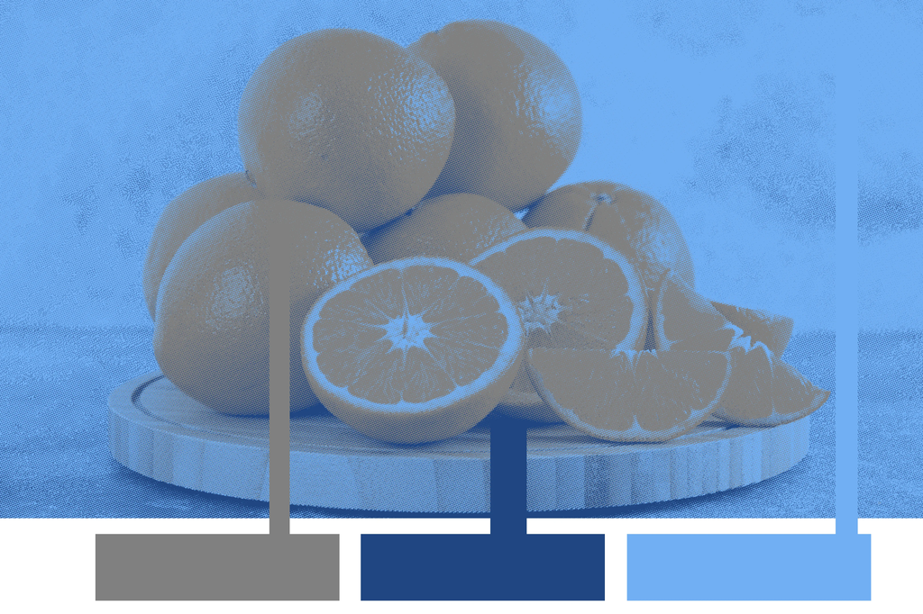

[figure not shown]

## How do we know something is true?

- Reality \(\xrightarrow{}\) Mind
- Reality \(\xleftarrow{}\) Mind

Kant lead a kind of “Copernican Revolution”

- our mind is part of reality and it **structures** our perception of reality
- we do not have **direct**/**unmediated** experience of reality.
- we have to reckon with how our perception is limited/flawed/misleading

## How do we know something is true?

Immanuel Kant in the *Critique of Pure Reason* distinguishes between:

*noumena*: the “things in themselves” in their existence **independent** of our perception

*phenomena*: the things **experienced** through the senses and filtered through the categories of our minds

## How do we know something is true?

This puts limits on what we can know to be true:

- We can **never** **know** the *noumena*. We can only seek to make inferences about the independent reality based on the **phenomena**.
- “Immanuel Kant, the arch-destroyer in the realm of thought, far surpassed in terrorism Maximilian Robespierre.” - Heinrich Heine

## Scientific Truth

We are interested in **scientific truth** attainable through the faculties of Understanding and Reason.

**scientific truth** *assumes*:

1. there is an **objective reality** (*noumena*) outside of our perceptions
2. we all *experience* the *same* objective reality with others
3. this reality operates under consistent rules
4. we can only learn about this objective reality **through our sense experiences** (*phenomena*) as filtered through our minds.
- All other assumptions, concepts, claims are open to challenge.

## Scientific Truth

Reason gives us the assumptions 2 and 3:

- we assume that, in principle, everything can be explained by a set of unified rules.

This is **dangerous** if we let Reason go, untethered to experience (need 4).

## Scientific Truth

Weber (a Kant stan) distinguishes science from “theology” in that

**In “theology”**: specific facts or values are taken as “revelation” or “faith” and cannot be questioned; other values or facts must be made to fit them. (Always a move to reason about things we can’t experience)

It makes **more assumptions** than science.

- “Theology” can be religious but also secular (e.g. free-market capitalism will lift all; history will progress toward equal society in which all share in owning means of production; technological development will be good for humanity)

## Scientific Truth

If we take up this idea of scientific truth, it has important implications for:

1. **which *types of claims*** we can judge to be true or false
2. **how *we use evidence*** to judge claims to be true or false.

## Scientific Truth and *Value*

In “Science as a Vocation”, Weber includes this line:

> **“Science is meaningless because it gives no answer to our question: the only question important for us: What shall we do and how shall we live?”** - Tolstoi
- Weber’s point: scientific truth cannot apply to claims about **value**; cannot address **normative claims**

## What is the best music?

## What is the best music?

Think, then write down…

- genre, artist, or song

## What is the best music?

In groups, discuss your beliefs about the best music.

Discuss: how would you prove who is right… **scientifically**?

## What is the best music?

## Scientific Truth and Values

Normative claims always reach **beyond empirical experience**.

- thus, we cannot use our sense experiences (phenomena) to learn about them.

Only **empirical claims** can be judged using scientific conception of truth.

## Conclusion

## Conclusion

1. What is a **claim**?
2. What types of **claims** are there: empirical and normative; descriptive and causal; value judgments and prescriptive claims
3. What do we mean by **truth**: scientific truth
4. What kinds of claims can be judged scientifically? Only empirical claims

Next class: HOW do we find truth, using science?